# hw2

**First, deal with data. Code of this chunk is from “downloadBridges.R”.**

```r
library(plyr)
library(choroplethr)
library(dplyr)
library(readr)
library(data.table)
```

```r
library(choroplethrMaps)
library(ggplot2)
dest = "https://www.fhwa.dot.gov/bridge/nbi/2016/delimited/AK16.txt"
tmp = fread(dest)
tmp = as.tbl(tmp)
tmp1 = read_csv(dest)
tmp2 = read_csv(dest, col_types = "c")  # could make them all characters...
classes = sapply(tmp, class)

states= read_csv("http://pages.stat.wisc.edu/~karlrohe/classes/data/stateAbv.txt")
states=states[-(1:12),]
states[51,] = c("WashDC", "DC")
states[52,] = c("Puerto Rico", "PR")
dat=list()

dest= rep("", 52)
for(i in 1:52) dest[i]=paste("https://www.fhwa.dot.gov/bridge/nbi/2016/delimited/", states[i,2],"16.txt", sep = "")
x16 = ldply(dest, fread, colClasses = classes)
save(x16, file = "allStates16.RData")

# take out the states that has many NAs.
M = x16
fun = function(x){ return(which(x>20)) }
bad =  is.na(M) %>% colSums %>% fun
M = M[,-bad]
```

** Get rid of the bad data. From previous discussion it is the columns of 11:13. **

```r
M = M[,-(11:13)]
M = as.tbl(M)
##using the data of Illinois.
iL = filter(M, STATE_CODE_001 == 17)
```

** Analysis and making plots. **

** compare the future average daily traffic with present, we can see they are positive correlation. **

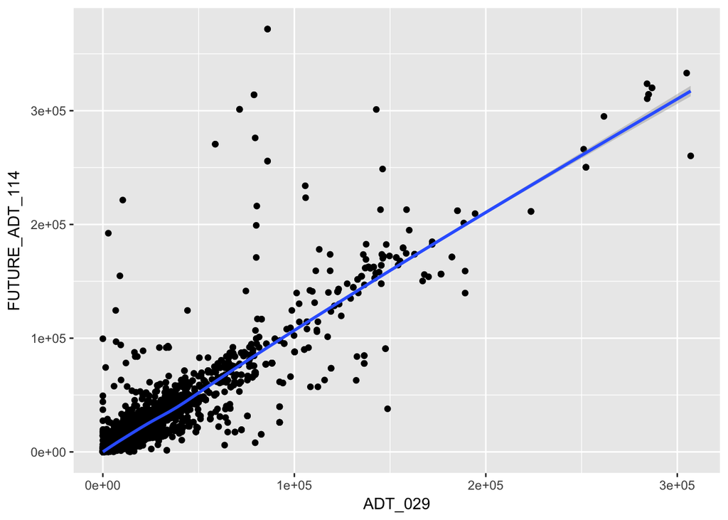

```r
ggplot(data = iL, mapping = aes(y = FUTURE_ADT_114, x = ADT_029)) +
  geom_point() +
  geom_smooth()
```

** Sum the four parts of safty as the bridges’ total safty condition, then try to figure out whether it is related to year and ADT. **

```r
iL$RAILINGS_036a = as.numeric(iL$RAILINGS_036A)
iL$RAILINGS_036a[is.na(iL$RAILINGS_036a)] = 0
iL$TRANSITIONS_036b = as.numeric(iL$TRANSITIONS_036B)
iL$TRANSITIONS_036b[is.na(iL$TRANSITIONS_036b)] = 0
iL$APPR_RAIL_036c = as.numeric(iL$APPR_RAIL_036C)
iL$APPR_RAIL_036c[is.na(iL$APPR_RAIL_036c)] = 0
iL$APPR_RAIL_END_036d = as.numeric(iL$APPR_RAIL_END_036D)
```

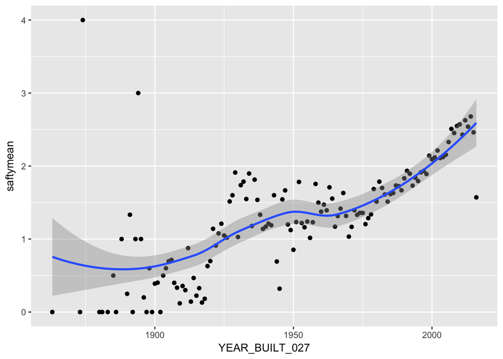

```r
iL$APPR_RAIL_END_036d[is.na(iL$APPR_RAIL_END_036d)] = 0
##this part is not efficient, but otherwise I don't know how to get rid of the NAs.

iL = mutate(iL, safty = as.character(iL$RAILINGS_036a + iL$TRANSITIONS_036b + iL$APPR_RAIL_036c + iL$APPR_RAIL_END_036d))

iL = filter(iL, YEAR_BUILT_027 > 1820)  #there is an outlier around 1800.
iL %>% group_by(YEAR_BUILT_027) %>%
  summarize(saftymean = mean(as.numeric(safty))) %>%
  ggplot(mapping = aes(x = YEAR_BUILT_027, y = saftymean)) +
  geom_point() +
  geom_smooth()
```

** We see there is an increased line of year and safty. Now we make plot of ADT and year, using safty as color. We can see that when ADT is higher and the built-time is closer, it is more likely that the bridge has more safty protection. **

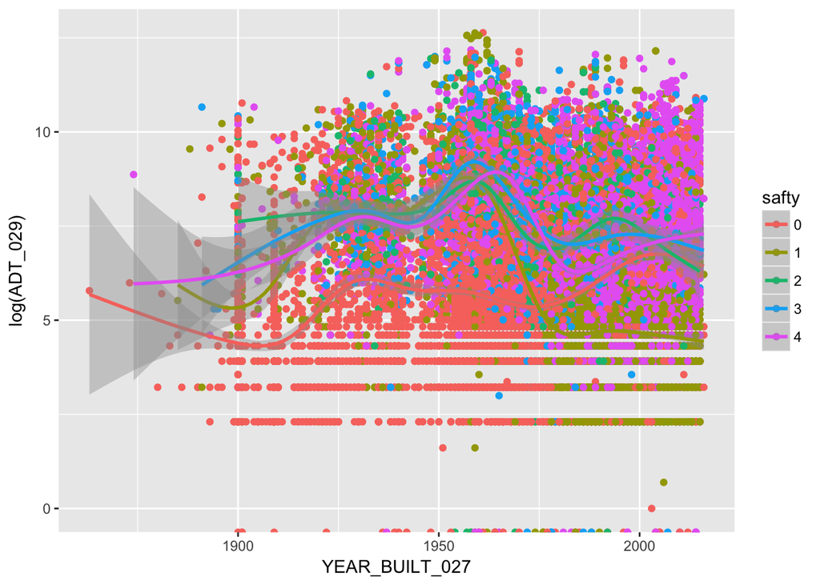

```r
ggplot(data = iL, mapping = aes(y = log(ADT_029), x =YEAR_BUILT_027, col = safty)) +
  geom_point() +
  geom_smooth()
```

** Now we make the map of the state. **

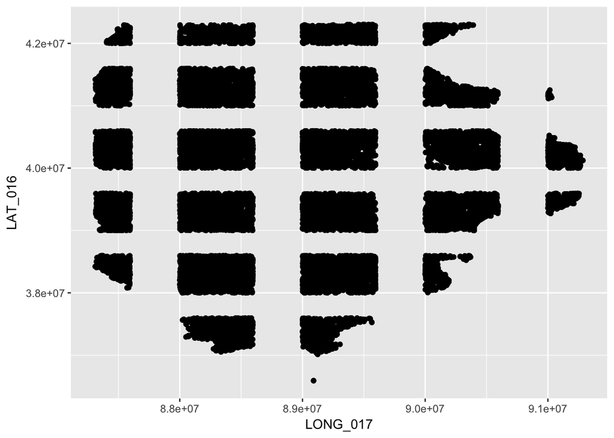

```r
iL = filter(M, STATE_CODE_001 == 17)
ggplot(data = iL) +geom_point(mapping = aes(y = LAT_016, x = LONG_017))
```

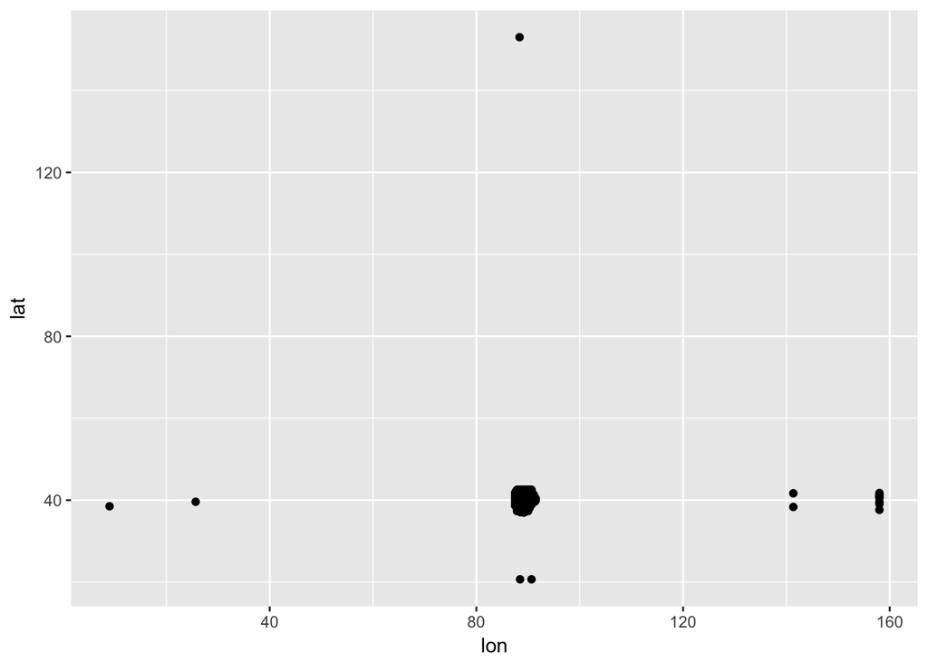

```r
min2dec = function(x){
  as.numeric(substr(x,1,2)) + as.numeric(substr(x,3,8))/6e+05 %>% return
}

iL = mutate(iL,lat = min2dec(LAT_016), lon = min2dec(LONG_017))
ggplot(data = iL) +
  geom_point(mapping = aes(y = lat, x = lon))
```

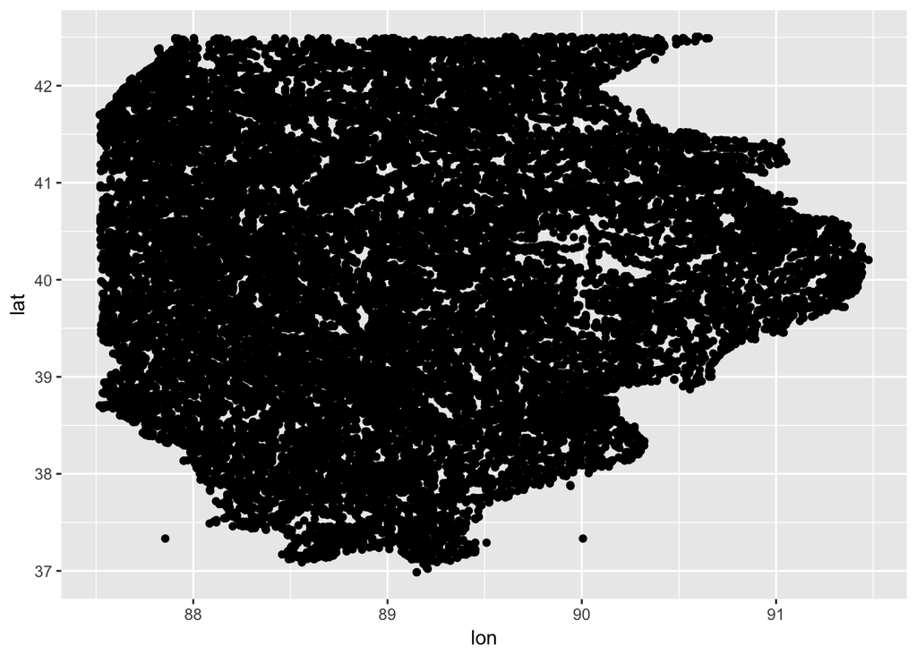

```r
iL = filter(iL, lat<80, lat>25, lon < 120, lon > 40)  ##Take out the outliers.
ggplot(data = iL) +
  geom_point(mapping = aes(y = lat, x = lon))
```

**To see if there are any specific kinds of bridge are required in some region. The plot shows that the central of the state more likely to have the concrete and steel.**

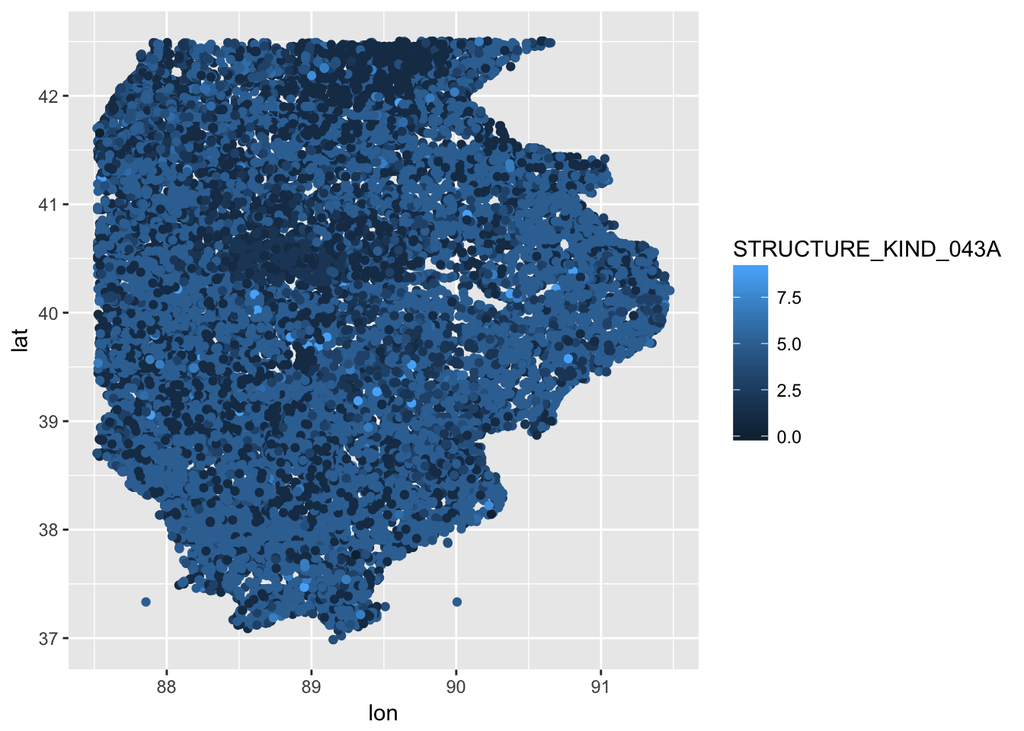

```r
ggplot(data = iL) +geom_point(mapping = aes(y = lat, x = lon,col = STRUCTURE_KIND_043A))
```